## IST 718 | LAB 3

01-23-20

# V1 DATA SOURCE: Coaches9

## O: OBTAIN

```python
import pandas as pd
data = pd.read_csv("Coaches9.csv")
```

```python
data.head()
```

|  | School | Conference | Coach | SchoolPay | TotalPay | Bonus | BonusPaid | AssistantPay | Buyout |
| --- | --- | --- | --- | --- | --- | --- | --- | --- | --- |
| 0 | Air Force | Mt. West | Troy Calhoun | 885000 | 885000 | 247000 | -- | $0 | -- |
| 1 | Akron | MAC | Terry Bowden | $411,000 | $412,500 | $225,000 | $50,000 | $0 | $688,500 |
| 2 | Alabama | SEC | Nick Saban | $8,307,000 | $8,307,000 | $1,100,000 | $500,000 | $0 | $33,600,000 |
| 3 | Alabama at Birmingham | C-USA | Bill Clark | $900,000 | $900,000 | $950,000 | $165,471 | $0 | $3,847,500 |
| 4 | Appalachian State | Sun Belt | Scott Satterfield | $712,500 | $712,500 | $295,000 | $145,000 | $0 | $2,160,417 |

## S: SCRUB

1. Change the columns with dollar amounts as strings to floats
2. Inspect and possibly replace missing values

```python
attrs = list(data[data.columns[3:]].columns)
data[attrs] = data[attrs].replace({'\$':'', ',': '', '--':None}, regex=True).astype('float')
```

```python
data.dtypes
```

```
School           object
Conference       object
Coach            object
SchoolPay       float64
TotalPay        float64
Bonus           float64
BonusPaid       float64
AssistantPay    float64
Buyout          float64
dtype: object
```

```python
data.isnull().sum()
```

```
School           0
Conference       0
Coach            0
SchoolPay        4
TotalPay         4
Bonus           22
BonusPaid       41
AssistantPay     0
Buyout          22
dtype: int64
```

### Replacing Missing Values

Four options:

1. Drop the schools with missing values
2. Drop the attributes with missing values (e.g. 'BonusPaid')
3. Replace the missing values with some value (e.g. mean, 0)
4. Find additional data

For V2, we are going to use #4 and a more advanced version of #3* taking within conference mean

```python
data.dropna(subset=['SchoolPay'], inplace=True)
```

```python
data.drop('BonusPaid', axis=1, inplace=True)
```

```python
median_bonus = data['Bonus'].median()
median_buyout = data['Buyout'].median()
data["Bonus"].fillna(median_bonus, inplace = True)
data["Buyout"].fillna(median_buyout, inplace = True)
```

```python
data.isnull().sum()
```

```
School          0
Conference      0
Coach           0
SchoolPay       0
TotalPay        0
Bonus           0
AssistantPay    0
Buyout          0
dtype: int64
```

## E: EXPLORE

```python
%matplotlib inline
import matplotlib.pyplot as plt
```

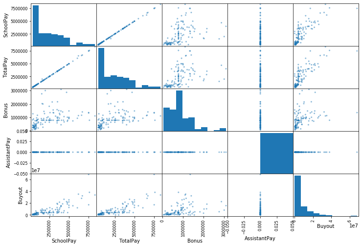

```python
from pandas.plotting import scatter_matrix
scatter_matrix(data, figsize=(12,8))
plt.show()
```

1. Drop either `SchoolPay` or `TotalPay`
2. Remove (or supplement) `AssistantPay`

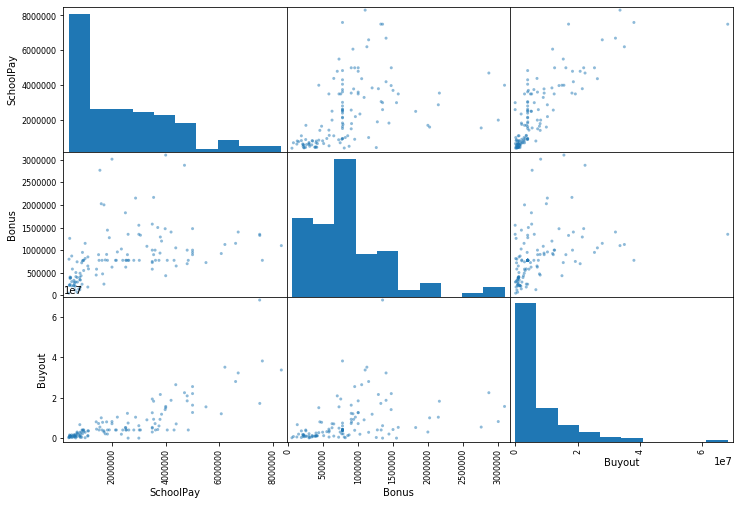

```python
data.drop(['TotalPay','AssistantPay'], axis=1, inplace=True)
scatter_matrix(data, figsize=(12,8))
plt.show()
```

```python
data.head()
```

|  | School | Conference | Coach | SchoolPay | Bonus | Buyout |
| --- | --- | --- | --- | --- | --- | --- |
| 0 | Air Force | Mt. West | Troy Calhoun | 885000.0 | 247000.0 | 4000000.0 |
| 1 | Akron | MAC | Terry Bowden | 411000.0 | 225000.0 | 688500.0 |
| 2 | Alabama | SEC | Nick Saban | 8307000.0 | 1100000.0 | 33600000.0 |
| 3 | Alabama at Birmingham | C-USA | Bill Clark | 900000.0 | 950000.0 | 3847500.0 |
| 4 | Appalachian State | Sun Belt | Scott Satterfield | 712500.0 | 295000.0 | 2160417.0 |

### Add More Data

We've lost a lot of data at this point and we need to add more. To do so we:

1. O: Obtain data
2. S: Scrub data
3. M: MERGE data! Add a "key" to both columns for merging

This sub OSM occured in an attached auxiliary file

#### + Add Win Loss Data

```python
data['school_key'] = data.apply(lambda x: ''.join(x['School'].lower().split(' '))[:8], axis=1)
```

```python
data
```

|  | School | Conference | Coach | SchoolPay | Bonus | Buyout | school_key |
| --- | --- | --- | --- | --- | --- | --- | --- |
| 0 | Air Force | Mt. West | Troy Calhoun | 885000.0 | 247000.0 | 4000000.0 | airforce |
| 1 | Akron | MAC | Terry Bowden | 411000.0 | 225000.0 | 688500.0 | akron |
| 2 | Alabama | SEC | Nick Saban | 8307000.0 | 1100000.0 | 33600000.0 | alabama |
| 3 | Alabama at Birmingham | C-USA | Bill Clark | 900000.0 | 950000.0 | 3847500.0 | alabamaa |
| 4 | Appalachian State | Sun Belt | Scott Satterfield | 712500.0 | 295000.0 | 2160417.0 | appalach |
| ... | ... | ... | ... | ... | ... | ... | ... |
| 124 | West Virginia | Big 12 | Dana Holgorsen | 3605000.0 | 1000000.0 | 7150000.0 | westvirg |
| 125 | Western Kentucky | C-USA | Mike Sanford Jr. | 800000.0 | 400000.0 | 1200000.0 | westernk |
| 126 | Western Michigan | MAC | Tim Lester | 800000.0 | 346500.0 | 800000.0 | westernm |
| 127 | Wisconsin | Big Ten | Paul Chryst | 3750000.0 | 775000.0 | 6000000.0 | wisconsi |
| 128 | Wyoming | Mt. West | Craig Bohl | 1412000.0 | 450000.0 | 8016667.0 | wyoming |

125 rows × 7 columns

```python
winloss = pd.read_csv('winloss_withkey.csv')
```

```python
test = data.copy()
```

```python
data_wl = test.merge(winloss, left_on="school_key", right_on="team_key")
```

```python
data_wl
```

|  | School | Conference | Coach | SchoolPay | Bonus | Buyout | school_key | Rank | Team | W | L | T | Pct | team_key |
| --- | --- | --- | --- | --- | --- | --- | --- | --- | --- | --- | --- | --- | --- | --- |
| 0 | Air Force | Mt. West | Troy Calhoun | 885000.0 | 247000.0 | 4000000.0 | airforce | 10 | Air Force (Mountain West) | 11 | 2 | 0 | 0.846 | airforce |
| 1 | Akron | MAC | Terry Bowden | 411000.0 | 225000.0 | 688500.0 | akron | 130 | Akron (MAC) | 0 | 12 | 0 | 0.000 | akron |
| 2 | Alabama | SEC | Nick Saban | 8307000.0 | 1100000.0 | 33600000.0 | alabama | 10 | Alabama (SEC) | 11 | 2 | 0 | 0.846 | alabama |
| 3 | Appalachian State | Sun Belt | Scott Satterfield | 712500.0 | 295000.0 | 2160417.0 | appalach | 3 | Appalachian State (Sun Belt) | 13 | 1 | 0 | 0.929 | appalach |
| 4 | Arizona | Pac-12 | Kevin Sumlin | 1600000.0 | 2025000.0 | 10000000.0 | arizona | 95 | Arizona (Pac-12) | 4 | 8 | 0 | 0.333 | arizona |
| ... | ... | ... | ... | ... | ... | ... | ... | ... | ... | ... | ... | ... | ... | ... |
| 121 | West Virginia | Big 12 | Dana Holgorsen | 3605000.0 | 1000000.0 | 7150000.0 | westvirg | 81 | West Virginia (Big 12) | 5 | 7 | 0 | 0.417 | westvirg |
| 122 | Western Kentucky | C-USA | Mike Sanford Jr. | 800000.0 | 400000.0 | 1200000.0 | westernk | 28 | Western Ky. (C-USA) | 9 | 4 | 0 | 0.692 | westernk |
| 123 | Western Michigan | MAC | Tim Lester | 800000.0 | 346500.0 | 800000.0 | westernm | 57 | Western Mich. (MAC) | 7 | 6 | 0 | 0.538 | westernm |
| 124 | Wisconsin | Big Ten | Paul Chryst | 3750000.0 | 775000.0 | 6000000.0 | wisconsi | 27 | Wisconsin (Big Ten) | 10 | 4 | 0 | 0.714 | wisconsi |
| 125 | Wyoming | Mt. West | Craig Bohl | 1412000.0 | 450000.0 | 8016667.0 | wyoming | 34 | Wyoming (Mountain West) | 8 | 5 | 0 | 0.615 | wyoming |

126 rows × 14 columns

#### + Add Stadium Size and Graduation Rate

```python
data_wl['team_coach_key'] = data_wl.apply(lambda x: (''.join(x['Coach'].split())+x['School'][:4]).lower(), axis=1)

gsr = pd.read_csv('c_modify_small.csv')
test = data_wl.copy()
data_wl_gsr = test.merge(gsr, left_on="team_coach_key", right_on="team_coach_key")
data_wl_gsr.columns
```

```
Index(['School', 'Conference', 'Coach', 'SchoolPay', 'Bonus', 'Buyout',
       'school_key', 'Rank', 'Team', 'W', 'L', 'T', 'Pct', 'team_key_x',
       'team_coach_key', 'school', 'stad_size', 'gsr', 'med_conf_sal',
       'seat_rank', 'combo_rank', 'true_rank', 'gs_rank', 'team_key_y',
       'coach', 'team_coach'],
      dtype='object')
```

```python
data_wl_gsr.isna().sum()
```

```
School            0
Conference        0
Coach             0
SchoolPay         0
Bonus             0
Buyout            0
school_key        0
Rank              0
Team              0
W                 0
L                 0
T                 0
Pct               0
team_key_x        0
team_coach_key    0
school            0
stad_size         0
gsr               0
med_conf_sal      0
seat_rank         0
combo_rank        0
true_rank         0
gs_rank           0
team_key_y        0
coach             0
team_coach        0
dtype: int64
```

```python
data_wl_gsr.seat_rank.value_counts()
```

```
20     5
88     3
64     3
26     2
103    2
      ..
86     1
87     1
90     1
91     1
128    1
Name: seat_rank, Length: 93, dtype: int64
```

```python
data_for_m = data_wl_gsr.drop(['school_key','Team','team_key_y',
                               'team_key_x', 'team_coach_key', 'coach', 'team_coach', 'school'], axis=1)
```

```python
data_for_m.columns
```

```
Index(['School', 'Conference', 'Coach', 'SchoolPay', 'Bonus', 'Buyout', 'Rank',
       'W', 'L', 'T', 'Pct', 'stad_size', 'gsr', 'med_conf_sal', 'seat_rank',
       'combo_rank', 'true_rank', 'gs_rank'],
      dtype='object')
```

```python
columns = ['school','conf','coach','school_pay', 'bonus', 'buyout', 'rank', 'W','L', 'T', 'ratio', 'stad_size', 'gsr', 'med_conf_sal', 'seat_rank',
       'combo_rank', 'true_rank', 'gs_rank' ]
data_for_m.columns = columns

data_for_m['med_conf_sal'] = data_for_m['med_conf_sal'].replace({'\$':'', ',': '', '--':0}, regex=True).astype('float')
data_for_m['stad_size'] = data_for_m['stad_size'].replace({'\$':'', ',': '', '--':0}, regex=True).astype('float')
```

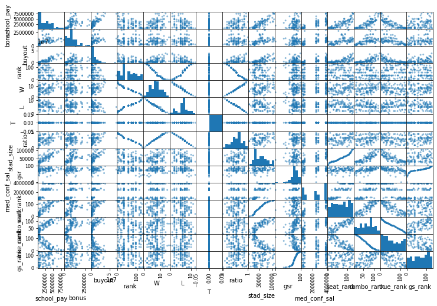

```python
scatter_matrix(data_for_m, figsize=(12,8))
plt.show()
```

```python
data_for_m.drop('T', axis=1, inplace=True)
```

```python
data_for_m.to_csv('data_for_m_v3.csv', index=False)
```

```python
data = data_for_m.copy()
```

```python
data.head()
```

|  | school | conf | coach | school_pay | bonus | buyout | rank | W | L | ratio | stad_size | gsr | med_conf_sal | seat_rank | combo_rank | true_rank | gs_rank |
| --- | --- | --- | --- | --- | --- | --- | --- | --- | --- | --- | --- | --- | --- | --- | --- | --- | --- |
| 0 | Air Force | Mt. West | Troy Calhoun | 885000.0 | 247000.0 | 4000000.0 | 10 | 11 | 2 | 0.846 | 46692.0 | 83 | 879288.0 | 60 | 65 | 67 | 97 |
| 1 | Akron | MAC | Terry Bowden | 411000.0 | 225000.0 | 688500.0 | 130 | 0 | 12 | 0.000 | 30000.0 | 45 | 492413.0 | 20 | 11 | 129 | 5 |
| 2 | Alabama | SEC | Nick Saban | 8307000.0 | 1100000.0 | 33600000.0 | 10 | 11 | 2 | 0.846 | 101821.0 | 79 | 3929800.0 | 124 | 111 | 5 | 84 |
| 3 | Appalachian State | Sun Belt | Scott Satterfield | 712500.0 | 295000.0 | 2160417.0 | 3 | 13 | 1 | 0.929 | 24050.0 | 57 | 675000.0 | 11 | 20 | 122 | 13 |
| 4 | Arizona | Pac-12 | Kevin Sumlin | 1600000.0 | 2025000.0 | 10000000.0 | 95 | 4 | 8 | 0.333 | 51811.0 | 74 | 2752233.0 | 73 | 66 | 62 | 60 |

# MODELS IN NEW WORKBOOK -- IST718_LAB3_V2_MODELS

```python
from sklearn.model_selection import train_test_split
train_set, test_set = train_test_split(data, test_size=0.2, random_state=42)

data = train_set.drop('school_pay', axis=1)
data_labels = train_set['school_pay'].copy()
```

```python
from sklearn.compose import ColumnTransformer

data_num = data.drop(['school', 'conf', 'coach'],axis =1)
num_attribs = list(data_num)
# cat_attribs = ['school','conf','coach']
cat_attribs = ['conf']
```

```python
from sklearn.pipeline import Pipeline
from sklearn.preprocessing import StandardScaler, OneHotEncoder
from sklearn.impute import SimpleImputer

num_pipeline = Pipeline([
    ('imputer', SimpleImputer(strategy="median")),
#     ('attribs_addr', CombinedAttributesAdder()),
    ('std_scaler', StandardScaler()),
])
```

```python
full_pipeline = ColumnTransformer([
    ('num', num_pipeline, num_attribs),
    ('cat', OneHotEncoder(), cat_attribs)
])
```

```python
data_prepared = full_pipeline.fit_transform(data)
# data.dtypes
```

## LINEAR REGRESSION

```python
from sklearn.linear_model import LinearRegression
lin_reg = LinearRegression()
lin_reg.fit(data_prepared, data_labels)
```

```
LinearRegression(copy_X=True, fit_intercept=True, n_jobs=None, normalize=False)
```

```python
from sklearn.metrics import mean_squared_error
from sklearn.model_selection import cross_val_score
import numpy as np

def display_scores(scores):
    print("Scores:", scores)
    print("Mean:", scores.mean())
    print("Stardard Deviation:", scores.std())
```

With only win-loss Scores: [ 627138.42590247 528461.92031606 740615.40460434 772653.8213664 421934.01610918 189714.87363032 913332.69201488 1110949.79108439 559555.59486329 1070420.75902697] Mean: 693477.7298918304 Stardard Deviation: 273911.52769763477

```python
scores = cross_val_score(lin_reg, data_prepared, data_labels, scoring="neg_mean_squared_error", cv=10)
lin_reg_rmse_scores = np.sqrt(-scores)
display_scores(lin_reg_rmse_scores)
```

```
Scores: [415759.78957098 335939.64663732 501500.88316226 291747.89978931
 330147.67958576 633813.27857645 803408.59272099 619665.81749927
 870888.03389595 389391.02186592]
Mean: 519226.26433042076
Stardard Deviation: 194064.85413625545
```

```python
data_whole = data_for_m.copy()
data_whole_y = data_whole['school_pay']
data_whole_X = data_whole.drop(['school_pay', 'school','coach'], axis=1)
```

```python
# data_whole_prepared = full_pipeline.fit_transform(data_whole_X)
# lin_reg.fit(data_whole_prepared, data_whole_y)
# lin_reg.fit()
# data_whole_X
# lin_reg.fit(data_whole_X, data_whole_y)
```

```python
# post_prediction = data_for_m.copy()
# post_prediction['prediction'] = lin_reg.predict(data_whole_prepared)
```

```python
# post_prediction['prediction_clear'] = post_prediction.apply(lambda x: '%.1f' % x['prediction'], axis=1)
```

```python
# post_prediction
```

## DECISION TREE

```python
from sklearn.tree import DecisionTreeRegressor
tree_reg = DecisionTreeRegressor()
tree_reg.fit(data_prepared, data_labels)
```

```
DecisionTreeRegressor(criterion='mse', max_depth=None, max_features=None,
                      max_leaf_nodes=None, min_impurity_decrease=0.0,
                      min_impurity_split=None, min_samples_leaf=1,
                      min_samples_split=2, min_weight_fraction_leaf=0.0,
                      presort=False, random_state=None, splitter='best')
```

With only win-loss Scores: [1061315.48217972 388101.64569291 838352.48061063 1310105.90729247 761111.21968192 813957.7190166 1191476.11762561 1072436.80091342 1048970.92139129 1632316.56249617] Mean: 1011814.4856900737 Stardard Deviation: 321697.2361820451

```python
scores = cross_val_score(tree_reg, data_prepared, data_labels, scoring="neg_mean_squared_error", cv=10)
tree_reg_rmse_scores = np.sqrt(-scores)
display_scores(tree_reg_rmse_scores)
```

```
Scores: [ 695960.02224984  190985.32132078  865917.51308222  495846.21566096
  715740.05141881  474615.74502199  801647.18805615 1653859.92548697
 1004394.43767377  704543.86440259]
Mean: 760351.028437408
Stardard Deviation: 368211.9671187752
```

## RANDOM FOREST

```python
from sklearn.ensemble import RandomForestRegressor
forest_reg = RandomForestRegressor()
forest_reg.fit(data_prepared, data_labels)
```

```
RandomForestRegressor(bootstrap=True, criterion='mse', max_depth=None,
                      max_features='auto', max_leaf_nodes=None,
                      min_impurity_decrease=0.0, min_impurity_split=None,
                      min_samples_leaf=1, min_samples_split=2,
                      min_weight_fraction_leaf=0.0, n_estimators=10,
                      n_jobs=None, oob_score=False, random_state=None,
                      verbose=0, warm_start=False)
```

With only win-loss Scores: [ 673351.8422406 606464.01825049 425498.26999178 1090543.6350158 690811.54849218 850426.329261 839837.59854235 1300692.87382977 816062.72166777 1095827.29603885] Mean: 838951.6133330595 Stardard Deviation: 248497.0665433372

```python
scores = cross_val_score(forest_reg, data_prepared, data_labels, scoring="neg_mean_squared_error", cv=10)
forest_reg_rmse_scores = np.sqrt(-scores)
display_scores(forest_reg_rmse_scores)
```

```
Scores: [ 468710.30629126  356629.96098513  688266.15774732  622175.40880706
  572174.37416687  601459.50130731  997561.09378467  565678.85222655
 1121408.95217627  549767.80651937]
Mean: 654383.2414011809
Stardard Deviation: 221262.96170275135
```

## MORE MODELING

```python
import statsmodels.formula.api as smf
```

# MODEL 1

```python
data = data_for_m.copy()
my_model = str('school_pay ~ bonus + rank + buyout')
train_model_fit = smf.ols(my_model, data = train_set).fit()
print(train_model_fit.summary())
```

```
                            OLS Regression Results
==============================================================================
Dep. Variable:             school_pay   R-squared:                       0.732
Model:                            OLS   Adj. R-squared:                  0.723
Method:                 Least Squares   F-statistic:                     82.76
Date:                Fri, 24 Jan 2020   Prob (F-statistic):           6.54e-26
Time:                        16:19:53   Log-Likelihood:                -1443.7
No. Observations:                  95   AIC:                             2895.
Df Residuals:                      91   BIC:                             2906.
Df Model:                           3
Covariance Type:            nonrobust
==============================================================================
                 coef    std err          t      P>|t|      [0.025      0.975]
------------------------------------------------------------------------------
Intercept   1.037e+06   2.78e+05      3.725      0.000    4.84e+05    1.59e+06
bonus          0.4464      0.209      2.137      0.035       0.032       0.861
rank       -2978.9510   2938.326     -1.014      0.313   -8815.574    2857.672
buyout         0.1705      0.013     12.721      0.000       0.144       0.197
==============================================================================
Omnibus:                       11.613   Durbin-Watson:                   2.075
Prob(Omnibus):                  0.003   Jarque-Bera (JB):               12.196
Skew:                           0.857   Prob(JB):                      0.00225
Kurtosis:                       3.380   Cond. No.                     3.31e+07
==============================================================================

Warnings:
[1] Standard Errors assume that the covariance matrix of the errors is correctly specified.
[2] The condition number is large, 3.31e+07. This might indicate that there are
strong multicollinearity or other numerical problems.
```

# MODEL 2

```python
my_model = str('school_pay ~ conf + bonus + buyout')
train_model_fit = smf.ols(my_model, data = train_set).fit()
print(train_model_fit.summary())
```

```
                            OLS Regression Results
==============================================================================
Dep. Variable:             school_pay   R-squared:                       0.881
Model:                            OLS   Adj. R-squared:                  0.865
Method:                 Least Squares   F-statistic:                     55.87
Date:                Fri, 24 Jan 2020   Prob (F-statistic):           1.20e-33
Time:                        16:19:53   Log-Likelihood:                -1405.1
No. Observations:                  95   AIC:                             2834.
Df Residuals:                      83   BIC:                             2865.
Df Model:                          11
Covariance Type:            nonrobust
====================================================================================
                       coef    std err          t      P>|t|      [0.025      0.975]
------------------------------------------------------------------------------------
Intercept         1.489e+06   3.18e+05      4.680      0.000    8.56e+05    2.12e+06
conf[T.ACC]       8.803e+05   3.59e+05      2.455      0.016    1.67e+05    1.59e+06
conf[T.Big 12]    1.408e+06   3.87e+05      3.640      0.000    6.39e+05    2.18e+06
conf[T.Big Ten]   1.542e+06   3.61e+05      4.275      0.000    8.24e+05    2.26e+06
conf[T.Ind.]     -6.208e+05   4.46e+05     -1.393      0.167   -1.51e+06    2.66e+05
conf[T.MAC]      -9.176e+05   3.71e+05     -2.477      0.015   -1.65e+06   -1.81e+05
conf[T.Mt. West] -6.707e+05   3.63e+05     -1.850      0.068   -1.39e+06    5.05e+04
conf[T.Pac-12]     7.94e+05   3.74e+05      2.123      0.037    5.02e+04    1.54e+06
conf[T.SEC]       1.656e+06   3.59e+05      4.608      0.000    9.41e+05    2.37e+06
conf[T.Sun Belt] -8.755e+05    3.6e+05     -2.433      0.017   -1.59e+06    -1.6e+05
bonus               -0.3289      0.193     -1.707      0.092      -0.712       0.054
buyout               0.1225      0.011     11.647      0.000       0.102       0.143
==============================================================================
Omnibus:                       20.520   Durbin-Watson:                   1.955
Prob(Omnibus):                  0.000   Jarque-Bera (JB):               61.965
Skew:                           0.623   Prob(JB):                     3.50e-14
Kurtosis:                       6.755   Cond. No.                     1.57e+08
==============================================================================

Warnings:
[1] Standard Errors assume that the covariance matrix of the errors is correctly specified.
[2] The condition number is large, 1.57e+08. This might indicate that there are
strong multicollinearity or other numerical problems.
```

```python
1.489e+06 + 8.803e+05
# + -0.3289(bonus) + 0.1225(buyout)
```

```
2369300.0
```

# MODEL 3

```python
my_model = str('school_pay ~ conf + buyout')
train_model_fit = smf.ols(my_model, data = train_set).fit()
print(train_model_fit.summary())
```

```
                            OLS Regression Results
==============================================================================
Dep. Variable:             school_pay   R-squared:                       0.877
Model:                            OLS   Adj. R-squared:                  0.862
Method:                 Least Squares   F-statistic:                     59.80
Date:                Fri, 24 Jan 2020   Prob (F-statistic):           6.16e-34
Time:                        16:19:53   Log-Likelihood:                -1406.7
No. Observations:                  95   AIC:                             2835.
Df Residuals:                      84   BIC:                             2864.
Df Model:                          10
Covariance Type:            nonrobust
====================================================================================
                       coef    std err          t      P>|t|      [0.025      0.975]
------------------------------------------------------------------------------------
Intercept         1.243e+06   2.87e+05      4.333      0.000    6.73e+05    1.81e+06
conf[T.ACC]       7.582e+05   3.55e+05      2.134      0.036    5.17e+04    1.46e+06
conf[T.Big 12]    1.415e+06   3.91e+05      3.617      0.001    6.37e+05    2.19e+06
conf[T.Big Ten]   1.484e+06   3.63e+05      4.087      0.000    7.62e+05    2.21e+06
conf[T.Ind.]     -5.425e+05   4.48e+05     -1.210      0.230   -1.43e+06    3.49e+05
conf[T.MAC]       -7.92e+05   3.67e+05     -2.157      0.034   -1.52e+06   -6.17e+04
conf[T.Mt. West] -6.262e+05   3.66e+05     -1.712      0.091   -1.35e+06    1.01e+05
conf[T.Pac-12]    5.776e+05   3.56e+05      1.623      0.108    -1.3e+05    1.29e+06
conf[T.SEC]       1.531e+06   3.56e+05      4.303      0.000    8.23e+05    2.24e+06
conf[T.Sun Belt] -7.309e+05   3.54e+05     -2.066      0.042   -1.43e+06   -2.75e+04
buyout               0.1213      0.011     11.429      0.000       0.100       0.142
==============================================================================
Omnibus:                       17.441   Durbin-Watson:                   1.990
Prob(Omnibus):                  0.000   Jarque-Bera (JB):               42.045
Skew:                           0.589   Prob(JB):                     7.41e-10
Kurtosis:                       6.039   Cond. No.                     1.56e+08
==============================================================================

Warnings:
[1] Standard Errors assume that the covariance matrix of the errors is correctly specified.
[2] The condition number is large, 1.56e+08. This might indicate that there are
strong multicollinearity or other numerical problems.
```

```python
1.243e+06 + 7.582e+05
# + 0.1213(buyout)
```

```
2001200.0
```

# MODEL 4

## RESPONSE: school_pay | PREDICTORS: conf

```python
my_model = str('school_pay ~ conf')
train_model_fit = smf.ols(my_model, data = train_set).fit()
print(train_model_fit.summary())
```

```
                            OLS Regression Results
==============================================================================
Dep. Variable:             school_pay   R-squared:                       0.685
Model:                            OLS   Adj. R-squared:                  0.652
Method:                 Least Squares   F-statistic:                     20.57
Date:                Fri, 24 Jan 2020   Prob (F-statistic):           6.49e-18
Time:                        16:19:54   Log-Likelihood:                -1451.3
No. Observations:                  95   AIC:                             2923.
Df Residuals:                      85   BIC:                             2948.
Df Model:                           9
Covariance Type:            nonrobust
====================================================================================
                       coef    std err          t      P>|t|      [0.025      0.975]
------------------------------------------------------------------------------------
Intercept         1.767e+06    4.5e+05      3.924      0.000    8.72e+05    2.66e+06
conf[T.ACC]       1.838e+06   5.44e+05      3.376      0.001    7.55e+05    2.92e+06
conf[T.Big 12]    2.697e+06   5.96e+05      4.528      0.000    1.51e+06    3.88e+06
conf[T.Big Ten]   2.707e+06   5.51e+05      4.910      0.000    1.61e+06     3.8e+06
conf[T.Ind.]     -7.675e+05   7.12e+05     -1.078      0.284   -2.18e+06    6.48e+05
conf[T.MAC]      -1.171e+06   5.81e+05     -2.014      0.047   -2.33e+06    -1.5e+04
conf[T.Mt. West] -6.408e+05   5.81e+05     -1.103      0.273    -1.8e+06    5.15e+05
conf[T.Pac-12]    1.153e+06    5.6e+05      2.061      0.042    4.06e+04    2.27e+06
conf[T.SEC]       2.424e+06   5.51e+05      4.397      0.000    1.33e+06    3.52e+06
conf[T.Sun Belt] -1.106e+06    5.6e+05     -1.975      0.051   -2.22e+06    7186.614
==============================================================================
Omnibus:                       27.553   Durbin-Watson:                   1.947
Prob(Omnibus):                  0.000   Jarque-Bera (JB):               57.186
Skew:                           1.090   Prob(JB):                     3.82e-13
Kurtosis:                       6.114   Cond. No.                         13.6
==============================================================================

Warnings:
[1] Standard Errors assume that the covariance matrix of the errors is correctly specified.
```

```python
1.767e+06 + 1.838e+06
```

```
3605000.0
```

# MODEL 5

## RESPONSE: school_pay | PREDICTORS: conf, ratio

```python
my_model = str('school_pay ~ conf + ratio')
train_model_fit = smf.ols(my_model, data = train_set).fit()
print(train_model_fit.summary())
```

```
                            OLS Regression Results
==============================================================================
Dep. Variable:             school_pay   R-squared:                       0.738
Model:                            OLS   Adj. R-squared:                  0.707
Method:                 Least Squares   F-statistic:                     23.71
Date:                Fri, 24 Jan 2020   Prob (F-statistic):           1.75e-20
Time:                        16:25:25   Log-Likelihood:                -1442.5
No. Observations:                  95   AIC:                             2907.
Df Residuals:                      84   BIC:                             2935.
Df Model:                          10
Covariance Type:            nonrobust
====================================================================================
                       coef    std err          t      P>|t|      [0.025      0.975]
------------------------------------------------------------------------------------
Intercept         6.742e+05    4.9e+05      1.375      0.173   -3.01e+05    1.65e+06
conf[T.ACC]       1.765e+06      5e+05      3.534      0.001    7.72e+05    2.76e+06
conf[T.Big 12]    2.467e+06   5.49e+05      4.494      0.000    1.38e+06    3.56e+06
conf[T.Big Ten]    2.66e+06   5.06e+05      5.259      0.000    1.65e+06    3.67e+06
conf[T.Ind.]     -5.567e+05   6.55e+05     -0.850      0.398   -1.86e+06    7.46e+05
conf[T.MAC]       -9.97e+05   5.35e+05     -1.864      0.066   -2.06e+06    6.64e+04
conf[T.Mt. West] -5.329e+05   5.34e+05     -0.998      0.321   -1.59e+06    5.28e+05
conf[T.Pac-12]    1.109e+06   5.13e+05      2.161      0.034    8.83e+04    2.13e+06
conf[T.SEC]       2.322e+06   5.06e+05      4.586      0.000    1.32e+06    3.33e+06
conf[T.Sun Belt] -1.274e+06   5.15e+05     -2.475      0.015    -2.3e+06    -2.5e+05
ratio             2.061e+06   4.99e+05      4.127      0.000    1.07e+06    3.05e+06
==============================================================================
Omnibus:                       18.217   Durbin-Watson:                   2.055
Prob(Omnibus):                  0.000   Jarque-Bera (JB):               32.977
Skew:                           0.754   Prob(JB):                     6.90e-08
Kurtosis:                       5.461   Cond. No.                         15.5
==============================================================================

Warnings:
[1] Standard Errors assume that the covariance matrix of the errors is correctly specified.
```

```python
6.742e+05 +  1.765e+06 + (2.061e+06*0.417)
```

```
3298637.0
```

```python
my_model = str('school_pay ~ conf + rank')
train_model_fit = smf.ols(my_model, data = train_set).fit()
print(train_model_fit.summary())
```

```
                            OLS Regression Results
==============================================================================
Dep. Variable:             school_pay   R-squared:                       0.733
Model:                            OLS   Adj. R-squared:                  0.701
Method:                 Least Squares   F-statistic:                     23.03
Date:                Fri, 24 Jan 2020   Prob (F-statistic):           4.16e-20
Time:                        16:29:07   Log-Likelihood:                -1443.5
No. Observations:                  95   AIC:                             2909.
Df Residuals:                      84   BIC:                             2937.
Df Model:                          10
Covariance Type:            nonrobust
====================================================================================
                       coef    std err          t      P>|t|      [0.025      0.975]
------------------------------------------------------------------------------------
Intercept         2.467e+06   4.55e+05      5.420      0.000    1.56e+06    3.37e+06
conf[T.ACC]        1.72e+06   5.05e+05      3.402      0.001    7.15e+05    2.73e+06
conf[T.Big 12]    2.406e+06   5.57e+05      4.318      0.000     1.3e+06    3.51e+06
conf[T.Big Ten]   2.663e+06   5.11e+05      5.208      0.000    1.65e+06    3.68e+06
conf[T.Ind.]     -6.251e+05   6.61e+05     -0.946      0.347   -1.94e+06    6.89e+05
conf[T.MAC]      -1.041e+06    5.4e+05     -1.928      0.057   -2.11e+06    3.25e+04
conf[T.Mt. West]  -5.69e+05   5.39e+05     -1.055      0.294   -1.64e+06    5.03e+05
conf[T.Pac-12]    1.065e+06   5.19e+05      2.050      0.043    3.21e+04     2.1e+06
conf[T.SEC]        2.34e+06   5.12e+05      4.573      0.000    1.32e+06    3.36e+06
conf[T.Sun Belt] -1.269e+06   5.21e+05     -2.437      0.017    -2.3e+06   -2.33e+05
rank             -1.154e+04   2990.706     -3.859      0.000   -1.75e+04   -5594.947
==============================================================================
Omnibus:                       19.207   Durbin-Watson:                   2.055
Prob(Omnibus):                  0.000   Jarque-Bera (JB):               36.686
Skew:                           0.773   Prob(JB):                     1.08e-08
Kurtosis:                       5.623   Cond. No.                         862.
==============================================================================

Warnings:
[1] Standard Errors assume that the covariance matrix of the errors is correctly specified.
```

```python
2.467e+06 + 1.72e+06 + (-1.154e+04*81)
```

```
3252260.0
```

```python
my_model = str('school_pay ~ conf + stad_size + grad_rate')
train_model_fit = smf.ols(my_model, data = train_set).fit()
print(train_model_fit.summary())
```

[output not shown]

```python
train_model_fit.params[0] + train_model_fit.params[1] + (train_model_fit.params[-1] * syracuse['stad_size'])
# train_model_fit.params[-1]
```

[output not shown]

```python
syracuse = data[data['school'] == 'Syracuse']
```

```python
syracuse
```

[output not shown]

# I : INTERPRET

#### What is the recommended salary for the Syracuse football coach?

```python
data = data_for_m.copy()
```

```python
data[data['school'] == 'Syracuse']
```

|  | school | conf | coach | school_pay | bonus | buyout | rank | W | L | ratio | stad_size | gsr | med_conf_sal | seat_rank | combo_rank | true_rank | gs_rank |
| --- | --- | --- | --- | --- | --- | --- | --- | --- | --- | --- | --- | --- | --- | --- | --- | --- | --- |
| 92 | Syracuse | ACC | Dino Babers | 2401206.0 | 775000.0 | 4000000.0 | 81 | 5 | 7 | 0.417 | 49250.0 | 80 | 2458033.0 | 63 | 73 | 49 | 87 |

```python
len(data)
```

[output not shown]